# (Ford GoBike Exploratory & Explanatory Analysis)

## by (Aditya Khosla)

With increasing traffic congestion in the bay area, the development of transportation infrastructure is vital. A strong transportation infrastructure connects employees to companies, travelers to tourist attractions, students to schools and much more. In particular, the Ford GoBike program offers a biking transportation infrastructure to connect the people of the bay area to numerous locations in SF, East Bay and San Jose. The Ford GoBike infrastructure involves having locations where people can rent bikes at any station and drop them off at any station. As a result, the consumers never have to pay for an actual bike, deal with maintenance of a bike, or worry about having a bike being stolen. Currently, Ford GoBike offers annual memberships, day passes, and single ride plans to use their bikes. As a result of annual membership plans offering the most consistent revenue and demand for Ford GoBike, encouraging subscription of customers will heavily determine the growth of their biking infrastructure.

Data Variables:

bike_id  
bike_share_for_all_trip  
duration_sec  
end_station_id  
end_station_latitude  
end_station_longitude  
end_station_name  
end_time  
member_birth_year  
member_gender  
start_station_id  
start_station_latitude  
start_station_longitude  
start_station_name  
start_time  
user_type

## Preliminary Wrangling

```python
# import all packages and set plots to be embedded inline
import numpy as np
import pandas as pd
import matplotlib.pyplot as plt
import seaborn as sb
import os
import datetime
import glob
import requests
import zipfile
import io
%matplotlib inline
import gzip
import re
```

```python
import boto
import urllib3
import urllib
from bs4 import BeautifulSoup
from datetime import date,datetime
from math import sin, cos, sqrt, atan2,radians
```

```python
import seaborn as sb
```

## Gathering the data

```python
resposne1=requests.get('https://s3.amazonaws.com/baywheels-data')
```

```python
soup=BeautifulSoup(resposne1.content,'lxml')
```

```python
url_list=soup.findAll('key')
```

```python
urls=[]
for i in url_list:
    e=str(i).strip('</key>')
    urls.append(e)
```

```python
folder_name='FordBikeData'
```

```python
if not os.path.exists(folder_name):
    os.makedirs(folder_name)
pd.read_csv('https://s3.amazonaws.com/baywheels-data/2017-fordgobike-tripdata.csv').to_csv('{}/2017-fordgobike-tripdata.csv'.format(folder_name))
```

```python
##Unzipping the file and storing it in the FolderDirectory
for url in urls[1:-1]:
    url1='https://s3.amazonaws.com/baywheels-data/'+ url
    response=requests.get(url1)
    unzip_file=zipfile.ZipFile(io.BytesIO(response.content))
    unzip_file.extractall(folder_name)
```

```python
path=folder_name
```

```python
all_files=glob.glob(os.path.join(path,"*.csv"))
```

```python
df=pd.concat((pd.read_csv(f) for f in all_files),ignore_index=True)
```

```python
df.shape
```

```
(3828132, 19)
```

```python
df.to_csv("FullBikeData.csv")
```

```python
##Reading the master file
bikedata=pd.read_csv("FullBikeData.csv")
```

## Assessing & Cleaning

```python
## Checking the shape of the data
bikedata.shape
```

```
(3828132, 20)
```

```python
##Checking the data
bikedata.head()
```

|  | Unnamed: 0 | Unnamed: 0.1 | Unnamed: 16 | bike_id | bike_share_for_all_trip | duration_sec | end_station_id | end_station_latitude | end_station_longitude | end_station_name | end_time | member_birth_year | member_gender | rental_access_method | start_station_id | start_station_latitude | start_station_longitude | start_station_name | start_time | user_type |
| --- | --- | --- | --- | --- | --- | --- | --- | --- | --- | --- | --- | --- | --- | --- | --- | --- | --- | --- | --- | --- |
| 0 | 0 | 0.0 | NaN | 96 | NaN | 80110 | 43.0 | 37.778768 | -122.415929 | San Francisco Public Library (Grove St at Hyde... | 2018-01-01 15:12:50.2450 | 1987.0 | Male | NaN | 74.0 | 37.776435 | -122.426244 | Laguna St at Hayes St | 2017-12-31 16:57:39.6540 | Customer |
| 1 | 1 | 1.0 | NaN | 88 | NaN | 78800 | 96.0 | 37.766210 | -122.426614 | Dolores St at 15th St | 2018-01-01 13:49:55.6170 | 1965.0 | Female | NaN | 284.0 | 37.784872 | -122.400876 | Yerba Buena Center for the Arts (Howard St at ... | 2017-12-31 15:56:34.8420 | Customer |
| 2 | 2 | 2.0 | NaN | 1094 | NaN | 45768 | 245.0 | 37.870348 | -122.267764 | Downtown Berkeley BART | 2018-01-01 11:28:36.8830 | NaN | NaN | NaN | 245.0 | 37.870348 | -122.267764 | Downtown Berkeley BART | 2017-12-31 22:45:48.4110 | Customer |
| 3 | 3 | 3.0 | NaN | 2831 | NaN | 62172 | 5.0 | 37.783899 | -122.408445 | Powell St BART Station (Market St at 5th St) | 2018-01-01 10:47:23.5310 | NaN | NaN | NaN | 60.0 | 37.774520 | -122.409449 | 8th St at Ringold St | 2017-12-31 17:31:10.6360 | Customer |
| 4 | 4 | 4.0 | NaN | 3167 | NaN | 43603 | 247.0 | 37.867789 | -122.265896 | Fulton St at Bancroft Way | 2018-01-01 02:29:57.5710 | 1997.0 | Female | NaN | 239.0 | 37.868813 | -122.258764 | Bancroft Way at Telegraph Ave | 2017-12-31 14:23:14.0010 | Subscriber |

```python
bikedata.tail()
```

|  | Unnamed: 0 | Unnamed: 0.1 | Unnamed: 16 | bike_id | bike_share_for_all_trip | duration_sec | end_station_id | end_station_latitude | end_station_longitude | end_station_name | end_time | member_birth_year | member_gender | rental_access_method | start_station_id | start_station_latitude | start_station_longitude | start_station_name | start_time | user_type |
| --- | --- | --- | --- | --- | --- | --- | --- | --- | --- | --- | --- | --- | --- | --- | --- | --- | --- | --- | --- | --- |
| 3828127 | 3828127 | NaN | app | 148227 | NaN | 850 | NaN | 37.870571 | -122.266337 | NaN | 2019-07-28 11:16:48 | 1995.0 | F | NaN | NaN | 37.888052 | -122.256561 | NaN | 2019-07-28 11:02:37 | Subscriber |
| 3828128 | 3828128 | NaN | app | 547361 | NaN | 589 | NaN | 37.869662 | -122.268208 | NaN | 2019-07-30 09:43:41 | 1981.0 | M | NaN | NaN | 37.888214 | -122.266832 | NaN | 2019-07-30 09:33:52 | Subscriber |
| 3828129 | 3828129 | NaN | clipper | 896256 | NaN | 370 | 254.0 | 37.880222 | -122.269592 | Vine St at Shattuck Ave | 2019-07-26 12:56:59 | 1964.0 | F | NaN | NaN | 37.891297 | -122.279522 | NaN | 2019-07-26 12:50:49 | Subscriber |
| 3828130 | 3828130 | NaN | app | 440004 | NaN | 593 | NaN | 37.881075 | -122.270206 | NaN | 2019-07-30 20:36:41 | NaN | ? | NaN | NaN | 37.892187 | -122.272764 | NaN | 2019-07-30 20:26:47 | Subscriber |
| 3828131 | 3828131 | NaN | app | 512019 | NaN | 1716 | 409.0 | 37.839543 | -122.298718 | 2100 Powell St | 2019-07-31 07:23:39 | 1983.0 | F | NaN | NaN | 37.895300 | -122.269339 | NaN | 2019-07-31 06:55:02 | Subscriber |

```python
##Programattic Assessment
bikedata.info(verbose=True,null_counts=True)
```

```
<class 'pandas.core.frame.DataFrame'>
RangeIndex: 3828132 entries, 0 to 3828131
Data columns (total 20 columns):
Unnamed: 0                 3828132 non-null int64
Unnamed: 0.1               519700 non-null float64
Unnamed: 16                29624 non-null object
bike_id                    3828132 non-null int64
bike_share_for_all_trip    3274915 non-null object
duration_sec               3828132 non-null int64
end_station_id             3793689 non-null float64
end_station_latitude       3828132 non-null float64
end_station_longitude      3828132 non-null float64
end_station_name           3793692 non-null object
end_time                   3828132 non-null object
member_birth_year          3548907 non-null float64
member_gender              3551938 non-null object
rental_access_method       3893 non-null object
start_station_id           3794417 non-null float64
start_station_latitude     3828132 non-null float64
start_station_longitude    3828132 non-null float64
start_station_name         3794421 non-null object
start_time                 3828132 non-null object
user_type                  3828132 non-null object
dtypes: float64(8), int64(3), object(9)
memory usage: 584.1+ MB
```

```python
##Creating list of column names to drop
a=bikedata.iloc[:,0:3].columns
```

```python
###Printing
a
```

```
Index(['Unnamed: 0', 'Unnamed: 0.1', 'Unnamed: 16'], dtype='object')
```

```python
###Creating Copy of Bike data
bikedata_copy =bikedata.copy()
```

```python
##Dropping the not required columns for now
bikedata_copy=bikedata_copy.drop(a,axis=1)
```

```python
##Checking
bikedata_copy.head()
```

|  | bike_id | bike_share_for_all_trip | duration_sec | end_station_id | end_station_latitude | end_station_longitude | end_station_name | end_time | member_birth_year | member_gender | rental_access_method | start_station_id | start_station_latitude | start_station_longitude | start_station_name | start_time | user_type |
| --- | --- | --- | --- | --- | --- | --- | --- | --- | --- | --- | --- | --- | --- | --- | --- | --- | --- |
| 0 | 96 | NaN | 80110 | 43.0 | 37.778768 | -122.415929 | San Francisco Public Library (Grove St at Hyde... | 2018-01-01 15:12:50.2450 | 1987.0 | Male | NaN | 74.0 | 37.776435 | -122.426244 | Laguna St at Hayes St | 2017-12-31 16:57:39.6540 | Customer |
| 1 | 88 | NaN | 78800 | 96.0 | 37.766210 | -122.426614 | Dolores St at 15th St | 2018-01-01 13:49:55.6170 | 1965.0 | Female | NaN | 284.0 | 37.784872 | -122.400876 | Yerba Buena Center for the Arts (Howard St at ... | 2017-12-31 15:56:34.8420 | Customer |
| 2 | 1094 | NaN | 45768 | 245.0 | 37.870348 | -122.267764 | Downtown Berkeley BART | 2018-01-01 11:28:36.8830 | NaN | NaN | NaN | 245.0 | 37.870348 | -122.267764 | Downtown Berkeley BART | 2017-12-31 22:45:48.4110 | Customer |
| 3 | 2831 | NaN | 62172 | 5.0 | 37.783899 | -122.408445 | Powell St BART Station (Market St at 5th St) | 2018-01-01 10:47:23.5310 | NaN | NaN | NaN | 60.0 | 37.774520 | -122.409449 | 8th St at Ringold St | 2017-12-31 17:31:10.6360 | Customer |
| 4 | 3167 | NaN | 43603 | 247.0 | 37.867789 | -122.265896 | Fulton St at Bancroft Way | 2018-01-01 02:29:57.5710 | 1997.0 | Female | NaN | 239.0 | 37.868813 | -122.258764 | Bancroft Way at Telegraph Ave | 2017-12-31 14:23:14.0010 | Subscriber |

```python
## Adding the sample to programatically assess the data
bikedata_copy.sample(50)
```

|  | bike_id | bike_share_for_all_trip | duration_sec | end_station_id | end_station_latitude | end_station_longitude | end_station_name | end_time | member_birth_year | member_gender | rental_access_method | start_station_id | start_station_latitude | start_station_longitude | start_station_name | start_time | user_type |
| --- | --- | --- | --- | --- | --- | --- | --- | --- | --- | --- | --- | --- | --- | --- | --- | --- | --- |
| 637482 | 952 | No | 967 | 8.0 | 37.799953 | -122.398525 | The Embarcadero at Vallejo St | 2018-02-22 08:59:46.0130 | 1990.0 | Male | NaN | 64.0 | 37.776754 | -122.399018 | 5th St at Brannan St | 2018-02-22 08:43:38.0940 | Subscriber |
| 2839545 | 5350 | No | 678 | 27.0 | 37.788059 | -122.391865 | Beale St at Harrison St | 2019-03-21 20:45:15.6180 | 1966.0 | Male | NaN | 104.0 | 37.767045 | -122.390833 | 4th St at 16th St | 2019-03-21 20:33:56.8120 | Subscriber |
| 2067686 | 2168 | No | 805 | 37.0 | 37.785000 | -122.395936 | 2nd St at Folsom St | 2018-10-08 17:07:11.9920 | 1976.0 | Male | NaN | 59.0 | 37.774814 | -122.418954 | S Van Ness Ave at Market St | 2018-10-08 16:53:46.9790 | Subscriber |
| 796154 | 1107 | No | 702 | 60.0 | 37.774520 | -122.409449 | 8th St at Ringold St | 2018-03-11 18:56:02.6410 | 1989.0 | Male | NaN | 86.0 | 37.769305 | -122.426826 | Market St at Dolores St | 2018-03-11 18:44:19.8760 | Subscriber |
| 2820750 | 6203 | No | 1559 | 324.0 | 37.788300 | -122.408531 | Union Square (Powell St at Post St) | 2019-03-24 18:56:57.1130 | 1988.0 | Female | NaN | 323.0 | 37.798014 | -122.405950 | Broadway at Kearny | 2019-03-24 18:30:57.5230 | Customer |
| 2606217 | 5639 | Yes | 972 | 203.0 | 37.795195 | -122.273970 | Webster St at 2nd St | 2019-02-24 18:46:59.0380 | 1972.0 | Male | NaN | 337.0 | 37.806970 | -122.266588 | Webster St at 19th St | 2019-02-24 18:30:46.8890 | Subscriber |
| 743616 | 212 | No | 607 | 81.0 | 37.775880 | -122.393170 | Berry St at 4th St | 2018-03-27 08:56:45.8570 | 1994.0 | Male | NaN | 61.0 | 37.776513 | -122.411306 | Howard St at 8th St | 2018-03-27 08:46:38.5100 | Subscriber |
| 1742102 | 4053 | Yes | 306 | 98.0 | 37.765052 | -122.421866 | Valencia St at 16th St | 2018-09-28 16:06:22.5160 | 1973.0 | Male | NaN | 86.0 | 37.769305 | -122.426826 | Market St at Dolores St | 2018-09-28 16:01:16.0900 | Subscriber |
| 676348 | 3221 | No | 975 | 79.0 | 37.773492 | -122.403672 | 7th St at Brannan St | 2018-02-12 08:48:16.1110 | 1979.0 | Female | NaN | 120.0 | 37.761420 | -122.426435 | Mission Dolores Park | 2018-02-12 08:32:00.2960 | Subscriber |
| 1252473 | 3887 | Yes | 895 | 323.0 | 37.798014 | -122.405950 | Broadway at Kearny | 2018-06-14 12:33:50.3450 | 1993.0 | Male | NaN | 50.0 | 37.780526 | -122.390288 | 2nd St at Townsend St | 2018-06-14 12:18:54.4000 | Subscriber |
| 2936080 | 3803 | Yes | 192 | 317.0 | 37.333955 | -121.877349 | San Salvador St at 9th St | 2019-03-12 08:59:11.2030 | 1996.0 | Male | NaN | 296.0 | 37.325998 | -121.877120 | 5th St at Virginia St | 2019-03-12 08:55:58.6990 | Subscriber |
| 3475103 | 2946 | Yes | 439 | 5.0 | 37.783899 | -122.408445 | Powell St BART Station (Market St at 5th St) | 2019-06-24 19:46:26.4220 | 1990.0 | Male | NaN | 321.0 | 37.780146 | -122.403071 | 5th St at Folsom | 2019-06-24 19:39:06.8230 | Subscriber |
| 3442481 | 2046 | No | 1809 | 75.0 | 37.773793 | -122.421239 | Market St at Franklin St | 2019-06-29 15:15:08.1090 | NaN | NaN | NaN | 5.0 | 37.783899 | -122.408445 | Powell St BART Station (Market St at 5th St) | 2019-06-29 14:44:58.9550 | Customer |
| 3713456 | 273 | No | 788 | 350.0 | 37.771431 | -122.405787 | 8th St at Brannan St | 2019-07-16 09:06:01.7880 | NaN | NaN | NaN | 139.0 | 37.751017 | -122.411901 | Garfield Square (25th St at Harrison St) | 2019-07-16 08:52:53.3860 | Customer |
| 1551379 | 2740 | No | 391 | 134.0 | 37.752428 | -122.420628 | Valencia St at 24th St | 2018-08-29 21:08:11.7460 | 1989.0 | Male | NaN | 129.0 | 37.758862 | -122.412544 | Harrison St at 20th St | 2018-08-29 21:01:40.6080 | Subscriber |
| 2651143 | 6095 | No | 370 | 81.0 | 37.775880 | -122.393170 | Berry St at 4th St | 2019-02-19 09:03:48.4800 | 1984.0 | Male | NaN | 36.0 | 37.783830 | -122.398870 | Folsom St at 3rd St | 2019-02-19 08:57:37.5930 | Customer |
| 3584294 | 2618 | No | 670 | 67.0 | 37.776639 | -122.395526 | San Francisco Caltrain Station 2 (Townsend St... | 2019-06-07 09:06:32.6580 | 1986.0 | Male | NaN | 23.0 | 37.791464 | -122.391034 | The Embarcadero at Steuart St | 2019-06-07 08:55:22.3510 | Subscriber |
| 3051508 | 3752 | No | 642 | 259.0 | 37.866249 | -122.299371 | Addison St at Fourth St | 2019-04-25 08:38:18.1470 | 1988.0 | Female | NaN | 250.0 | 37.873558 | -122.283093 | North Berkeley BART Station | 2019-04-25 08:27:35.8600 | Customer |
| 894897 | 3040 | No | 668 | 67.0 | 37.776639 | -122.395526 | San Francisco Caltrain Station 2 (Townsend St... | 2018-04-18 08:45:56.0190 | 1980.0 | Male | NaN | 23.0 | 37.791464 | -122.391034 | The Embarcadero at Steuart St | 2018-04-18 08:34:47.0240 | Subscriber |
| 836578 | 4068 | No | 490 | 66.0 | 37.778742 | -122.392741 | 3rd St at Townsend St | 2018-04-30 11:25:29.7360 | 1983.0 | Male | NaN | 81.0 | 37.775880 | -122.393170 | Berry St at 4th St | 2018-04-30 11:17:18.7800 | Subscriber |
| 717917 | 1746 | No | 657 | 133.0 | 37.755213 | -122.420975 | Valencia St at 22nd St | 2018-02-01 17:38:09.9940 | 1958.0 | Male | NaN | 129.0 | 37.758862 | -122.412544 | Harrison St at 20th St | 2018-02-01 17:27:12.6830 | Subscriber |
| 1649429 | 3436 | No | 1140 | 181.0 | 37.811377 | -122.265192 | Grand Ave at Webster St | 2018-08-14 07:44:48.3180 | 1975.0 | Male | NaN | 170.0 | 37.844493 | -122.261351 | Telegraph Ave at 58th St | 2018-08-14 07:25:47.3490 | Customer |
| 287185 | 1885 | NaN | 1401 | 172.0 | 37.841800 | -122.251535 | College Ave at Taft Ave | 2017-10-02 12:21:51.2680 | 1961.0 | Male | NaN | 194.0 | 37.811081 | -122.243268 | Lakeshore Ave at Trestle Glen Rd | 2017-10-02 11:58:29.3540 | Subscriber |
| 2438624 | 2682 | No | 625 | 21.0 | 37.789625 | -122.400811 | Montgomery St BART Station (Market St at 2nd St) | 2019-01-25 09:05:40.8540 | 1986.0 | Female | NaN | 67.0 | 37.776639 | -122.395526 | San Francisco Caltrain Station 2 (Townsend St... | 2019-01-25 08:55:15.5180 | Subscriber |
| 343496 | 133 | NaN | 10706 | 45.0 | 37.781752 | -122.405127 | 5th St at Howard St | 2017-09-15 17:20:13.5890 | NaN | NaN | NaN | 3.0 | 37.786375 | -122.404904 | Powell St BART Station (Market St at 4th St) | 2017-09-15 14:21:46.8090 | Customer |
| 3736394 | 1545 | No | 243 | 223.0 | 37.764765 | -122.420091 | 16th St Mission BART Station 2 | 2019-07-11 20:36:27.5560 | NaN | NaN | NaN | 100.0 | 37.767100 | -122.410662 | Bryant St at 15th St | 2019-07-11 20:32:23.8010 | Customer |
| 748813 | 3754 | No | 535 | 163.0 | 37.797320 | -122.265320 | Lake Merritt BART Station | 2018-03-26 08:28:09.2210 | 1988.0 | Male | NaN | 197.0 | 37.808848 | -122.249680 | El Embarcadero at Grand Ave | 2018-03-26 08:19:13.6620 | Subscriber |
| 1725626 | 3240 | No | 495 | 67.0 | 37.776639 | -122.395526 | San Francisco Caltrain Station 2 (Townsend St... | 2018-08-01 17:25:43.5710 | 1981.0 | Male | NaN | 5.0 | 37.783899 | -122.408445 | Powell St BART Station (Market St at 5th St) | 2018-08-01 17:17:28.1750 | Subscriber |
| 2286494 | 4731 | No | 222 | 4.0 | 37.785881 | -122.408915 | Cyril Magnin St at Ellis St | 2018-12-20 11:40:00.2020 | 1992.0 | Female | NaN | 349.0 | 37.781010 | -122.405666 | Howard St at Mary St | 2018-12-20 11:36:17.5250 | Subscriber |
| 453913 | 1691 | NaN | 998 | 20.0 | 37.791300 | -122.399051 | Mechanics Monument Plaza (Market St at Bush St) | 2017-08-09 08:30:21.6060 | 1965.0 | Male | NaN | 30.0 | 37.776598 | -122.395282 | San Francisco Caltrain (Townsend St at 4th St) | 2017-08-09 08:13:43.1300 | Subscriber |
| 2196484 | 4407 | No | 1234 | 115.0 | 37.765026 | -122.398773 | Jackson Playground | 2018-11-09 16:59:39.1370 | 1979.0 | Male | NaN | 22.0 | 37.789756 | -122.394643 | Howard St at Beale St | 2018-11-09 16:39:04.4760 | Customer |
| 2369196 | 2356 | No | 717 | 20.0 | 37.791300 | -122.399051 | Mechanics Monument Plaza (Market St at Bush St) | 2018-12-04 14:16:22.3660 | 1985.0 | Male | NaN | 41.0 | 37.781270 | -122.418740 | Golden Gate Ave at Polk St | 2018-12-04 14:04:25.1520 | Subscriber |
| 723270 | 1279 | No | 1016 | 67.0 | 37.776639 | -122.395526 | San Francisco Caltrain Station 2 (Townsend St... | 2018-03-31 11:55:37.1610 | 1976.0 | Male | NaN | 147.0 | 37.744067 | -122.421472 | 29th St at Tiffany Ave | 2018-03-31 11:38:40.9500 | Subscriber |
| 3137338 | 6116 | No | 402 | 323.0 | 37.798014 | -122.405950 | Broadway at Kearny | 2019-04-12 13:22:49.8490 | 1997.0 | Male | NaN | 20.0 | 37.791300 | -122.399051 | Mechanics Monument Plaza (Market St at Bush St) | 2019-04-12 13:16:07.5210 | Subscriber |
| 1133837 | 3962 | No | 726 | 21.0 | 37.789625 | -122.400811 | Montgomery St BART Station (Market St at 2nd St) | 2018-05-02 11:04:17.2930 | 1971.0 | Male | NaN | 343.0 | 37.783172 | -122.393572 | Bryant St at 2nd St | 2018-05-02 10:52:10.7090 | Subscriber |
| 3154219 | 3462 | Yes | 189 | 93.0 | 37.770407 | -122.391198 | 4th St at Mission Bay Blvd S | 2019-04-11 06:54:03.2760 | 1990.0 | Female | NaN | 81.0 | 37.775880 | -122.393170 | Berry St at 4th St | 2019-04-11 06:50:54.2350 | Subscriber |
| 3386812 | 4065 | No | 970 | 389.0 | 37.353062 | -121.891937 | Taylor St at 9th St | 2019-05-08 18:06:06.0220 | 1970.0 | Male | NaN | 312.0 | 37.329732 | -121.901782 | San Jose Diridon Station | 2019-05-08 17:49:55.4760 | Subscriber |
| 3482363 | 2510 | No | 4014 | 6.0 | 37.804770 | -122.403234 | The Embarcadero at Sansome St | 2019-06-23 18:20:57.9180 | NaN | NaN | NaN | 6.0 | 37.804770 | -122.403234 | The Embarcadero at Sansome St | 2019-06-23 17:14:03.0780 | Customer |
| 1383681 | 1968 | No | 492 | 50.0 | 37.780526 | -122.390288 | 2nd St at Townsend St | 2018-07-25 08:02:40.4140 | 1970.0 | Male | NaN | 16.0 | 37.794130 | -122.394430 | Steuart St at Market St | 2018-07-25 07:54:28.3060 | Subscriber |
| 490205 | 1889 | NaN | 4118 | 84.0 | 37.769201 | -122.433812 | Duboce Park | 2017-07-22 16:09:47.0650 | NaN | NaN | NaN | 107.0 | 37.763015 | -122.426497 | 17th St at Dolores St | 2017-07-22 15:01:08.5840 | Customer |
| 2591386 | 4506 | No | 692 | 194.0 | 37.811081 | -122.243268 | Lakeshore Ave at Trestle Glen Rd | 2019-02-27 09:07:59.4120 | 1988.0 | Male | NaN | 163.0 | 37.797320 | -122.265320 | Lake Merritt BART Station | 2019-02-27 08:56:27.2830 | Subscriber |
| 3091740 | 3326 | No | 440 | 130.0 | 37.757288 | -122.392051 | 22nd St Caltrain Station | 2019-04-18 18:21:01.4380 | 1983.0 | Male | NaN | 104.0 | 37.767045 | -122.390833 | 4th St at 16th St | 2019-04-18 18:13:40.5030 | Subscriber |
| 620987 | 872 | Yes | 3445 | 238.0 | 37.871719 | -122.273068 | MLK Jr Way at University Ave | 2018-02-27 14:10:14.2230 | 1977.0 | Male | NaN | 238.0 | 37.871719 | -122.273068 | MLK Jr Way at University Ave | 2018-02-27 13:12:48.3630 | Subscriber |
| 512257 | 1093 | NaN | 877 | 59.0 | 37.774814 | -122.418954 | S Van Ness Ave at Market St | 2017-07-07 08:50:36.3910 | 1981.0 | Male | NaN | 22.0 | 37.789756 | -122.394643 | Howard St at Beale St | 2017-07-07 08:35:58.6530 | Subscriber |
| 1544163 | 4430 | Yes | 3409 | 6.0 | 37.804770 | -122.403234 | The Embarcadero at Sansome St | 2018-08-31 01:02:57.7460 | 1986.0 | Male | NaN | 323.0 | 37.798014 | -122.405950 | Broadway at Kearny | 2018-08-31 00:06:08.2320 | Subscriber |
| 3823630 | 654087 | NaN | 950 | NaN | 37.872374 | -122.263888 | NaN | 2019-07-15 13:19:32 | 1998.0 | M | NaN | NaN | 37.860243 | -122.260438 | NaN | 2019-07-15 13:03:42 | Subscriber |
| 2529350 | 1931 | No | 496 | 44.0 | 37.781074 | -122.411738 | Civic Center/UN Plaza BART Station (Market St ... | 2019-01-10 08:34:39.8740 | 1992.0 | Male | NaN | 67.0 | 37.776639 | -122.395526 | San Francisco Caltrain Station 2 (Townsend St... | 2019-01-10 08:26:23.3110 | Subscriber |
| 180815 | 3160 | NaN | 476 | 50.0 | 37.780526 | -122.390288 | 2nd St at Townsend St - Coming Soon | 2017-11-01 09:54:17.5070 | 1977.0 | Male | NaN | 45.0 | 37.781752 | -122.405127 | 5th St at Howard St | 2017-11-01 09:46:20.6540 | Subscriber |
| 2416923 | 4807 | No | 201 | 338.0 | 37.803189 | -122.270579 | 13th St at Franklin St | 2019-01-28 13:09:08.2670 | 1988.0 | Male | NaN | 372.0 | 37.804037 | -122.262409 | Madison St at 17th St | 2019-01-28 13:05:46.8480 | Subscriber |
| 331069 | 2090 | NaN | 412 | 21.0 | 37.789625 | -122.400811 | Montgomery St BART Station (Market St at 2nd St) | 2017-09-19 17:14:00.9810 | 1990.0 | Female | NaN | 48.0 | 37.782411 | -122.392706 | 2nd St at S Park St | 2017-09-19 17:07:08.7920 | Subscriber |

```python
##Dropping the rental_access_method as we won't be needing it for the analysis
bikedata_copy=bikedata_copy.drop("rental_access_method",axis=1)
```

```python
##Checking
bikedata_copy.head()
```

|  | bike_id | bike_share_for_all_trip | duration_sec | end_station_id | end_station_latitude | end_station_longitude | end_station_name | end_time | member_birth_year | member_gender | start_station_id | start_station_latitude | start_station_longitude | start_station_name | start_time | user_type |
| --- | --- | --- | --- | --- | --- | --- | --- | --- | --- | --- | --- | --- | --- | --- | --- | --- |
| 0 | 96 | NaN | 80110 | 43.0 | 37.778768 | -122.415929 | San Francisco Public Library (Grove St at Hyde... | 2018-01-01 15:12:50.2450 | 1987.0 | Male | 74.0 | 37.776435 | -122.426244 | Laguna St at Hayes St | 2017-12-31 16:57:39.6540 | Customer |
| 1 | 88 | NaN | 78800 | 96.0 | 37.766210 | -122.426614 | Dolores St at 15th St | 2018-01-01 13:49:55.6170 | 1965.0 | Female | 284.0 | 37.784872 | -122.400876 | Yerba Buena Center for the Arts (Howard St at ... | 2017-12-31 15:56:34.8420 | Customer |
| 2 | 1094 | NaN | 45768 | 245.0 | 37.870348 | -122.267764 | Downtown Berkeley BART | 2018-01-01 11:28:36.8830 | NaN | NaN | 245.0 | 37.870348 | -122.267764 | Downtown Berkeley BART | 2017-12-31 22:45:48.4110 | Customer |
| 3 | 2831 | NaN | 62172 | 5.0 | 37.783899 | -122.408445 | Powell St BART Station (Market St at 5th St) | 2018-01-01 10:47:23.5310 | NaN | NaN | 60.0 | 37.774520 | -122.409449 | 8th St at Ringold St | 2017-12-31 17:31:10.6360 | Customer |
| 4 | 3167 | NaN | 43603 | 247.0 | 37.867789 | -122.265896 | Fulton St at Bancroft Way | 2018-01-01 02:29:57.5710 | 1997.0 | Female | 239.0 | 37.868813 | -122.258764 | Bancroft Way at Telegraph Ave | 2017-12-31 14:23:14.0010 | Subscriber |

```python
### Converting start time and end time into date and time format
bikedata_copy['end_time']=pd.to_datetime(bikedata_copy['end_time'])
bikedata_copy['start_time']=pd.to_datetime(bikedata_copy['start_time'])
```

```python
## Checking the change
bikedata_copy.info(verbose=True,null_counts=True)
```

```
<class 'pandas.core.frame.DataFrame'>
RangeIndex: 3828132 entries, 0 to 3828131
Data columns (total 16 columns):
bike_id                    3828132 non-null int64
bike_share_for_all_trip    3274915 non-null object
duration_sec               3828132 non-null int64
end_station_id             3793689 non-null float64
end_station_latitude       3828132 non-null float64
end_station_longitude      3828132 non-null float64
end_station_name           3793692 non-null object
end_time                   3828132 non-null datetime64[ns]
member_birth_year          3548907 non-null float64
member_gender              3551938 non-null object
start_station_id           3794417 non-null float64
start_station_latitude     3828132 non-null float64
start_station_longitude    3828132 non-null float64
start_station_name         3794421 non-null object
start_time                 3828132 non-null datetime64[ns]
user_type                  3828132 non-null object
dtypes: datetime64[ns](2), float64(7), int64(2), object(5)
memory usage: 467.3+ MB
```

```python
##Converting bike_id,start_station_id,end_station_id into string becasue id should be strings
```

```python
bikedata_copy['bike_id']=bikedata_copy['bike_id'].astype('str')
bikedata_copy['end_station_id']=bikedata_copy['end_station_id'].astype('str')
bikedata_copy['start_station_id']=bikedata_copy['start_station_id'].astype('str')
```

```python
##Filtering data greater than equal to 1940 becuse I believe it will be very dificult for more than 80 years people to ride a bike
bikedata_copy=bikedata_copy.query("member_birth_year >= 1940")
```

```python
##Extracting month,year,day,time,month,day of the week
bikedata_copy['year'] = bikedata_copy['start_time'].dt.year
bikedata_copy['day'] = bikedata_copy['start_time'].dt.day
bikedata_copy['starttime'] = bikedata_copy['start_time'].dt.time
bikedata_copy['endtime']=bikedata_copy['end_time'].dt.time
bikedata_copy['month']=bikedata_copy['start_time'].dt.month
bikedata_copy['hour']=bikedata_copy['start_time'].dt.hour
```

```python
##Calculating the age
today=date.today()
bikedata_copy['member_age']= today.year-bikedata_copy['member_birth_year']
```

```python
##Checking
bikedata_copy['member_age'].value_counts()
```

```
31.0    201987
30.0    175209
32.0    171670
29.0    167325
28.0    161697
26.0    159146
34.0    155786
33.0    153481
27.0    146584
35.0    141682
25.0    133262
36.0    128512
37.0    122680
24.0    114748
39.0    100116
38.0     99311
40.0     78751
23.0     77734
42.0     72898
41.0     70272
44.0     64291
45.0     56747
43.0     56502
22.0     54931
46.0     50701
51.0     47905
48.0     47747
21.0     45908
47.0     43226
54.0     41996
         ...
52.0     33234
20.0     31215
56.0     29865
55.0     25965
53.0     25059
57.0     24465
58.0     21272
59.0     18135
60.0     16244
61.0     15619
19.0     14844
62.0     12815
63.0     11155
65.0      8273
64.0      5658
67.0      5516
69.0      4130
66.0      3793
68.0      3588
70.0      2777
72.0      2698
74.0      2403
71.0      1857
18.0       885
76.0       857
77.0       668
75.0       582
73.0       485
78.0       273
79.0        71
Name: member_age, Length: 62, dtype: int64
```

```python
## Creating function for calculating the distance from latitude and logitude of the start place and end place
dist=[]
for i,j,k,n in zip(bikedata_copy['start_station_latitude'],bikedata_copy['start_station_longitude'],
                   bikedata_copy['end_station_latitude'],bikedata_copy['end_station_longitude']):
    ## approximate radius of earth
    R= 6373.0
    lat1=radians(i)
    lon1=radians(j)
    lat2=radians(k)
    lon2=radians(n)

    dlat= lat2-lat1
    dlon= lon2-lon1

    a=sin(dlat / 2)**2 + cos(lat1) * cos(lat2) * sin(dlon / 2)**2
    c=2 * atan2(sqrt(a), sqrt(1 - a))

    distance = R * c
    dist.append(distance)
```

```python
bikedata_copy['distance_km']=dist
```

```python
##testing
bikedata_copy['distance_km'].head(10)
```

```
0     0.943227
1     3.070691
4     0.636539
6     0.000000
12    1.517825
13    1.517825
15    1.050592
16    1.050592
18    2.857230
19    2.860139
Name: distance_km, dtype: float64
```

```python
## Testing
## approximate radius of earth
R= 6373.0
lat1=radians(bikedata_copy['start_station_latitude'][0])
lon1=radians(bikedata_copy['start_station_longitude'][0])
lat2=radians(bikedata_copy['end_station_latitude'][0])
lon2=radians(bikedata_copy['end_station_longitude'][0])

dlat= lat2-lat1
dlon= lon2-lon1

a=sin(dlat / 2)**2 + cos(lat1) * cos(lat2) * sin(dlon / 2)**2
c=2 * atan2(sqrt(a), sqrt(1 - a))

dist_test = R * c
```

```python
dist_test
```

```
0.9432271558663856
```

> Load in your dataset and describe its properties through the questions below. Try and motivate your exploration goals through this section.

```python
bikedata_copy.info()
```

```
<class 'pandas.core.frame.DataFrame'>
Int64Index: 3544157 entries, 0 to 3828131
Data columns (total 24 columns):
bike_id                    object
bike_share_for_all_trip    object
duration_sec               int64
end_station_id             object
end_station_latitude       float64
end_station_longitude      float64
end_station_name           object
end_time                   datetime64[ns]
member_birth_year          float64
member_gender              object
start_station_id           object
start_station_latitude     float64
start_station_longitude    float64
start_station_name         object
start_time                 datetime64[ns]
user_type                  object
year                       int64
day                        int64
starttime                  object
endtime                    object
month                      int64
hour                       int64
member_age                 float64
distance_km                float64
dtypes: datetime64[ns](2), float64(7), int64(5), object(10)
memory usage: 676.0+ MB
```

### What is the structure of your dataset?

2.Column name -> bike_id', 'bike_share_for_all_trip', 'duration_sec', 'end_station_id', 'end_station_latitude', 'end_station_longitude', 'end_station_name', 'end_time', 'member_birth_year', 'member_gender', 'start_station_id', 'start_station_latitude', 'start_station_longitude', 'start_station_name', 'start_time', 'user_type', 'year', 'day', 'starttime', 'endtime', 'month', 'member_age', 'distance_km' 3.Datatypes for each column name:

a. bike_id string

b. bike_share_for_all_trip category

c. duration_sec int64

d.end_station_id object

e.end_station_latitude float

f.end_station_longitude float

g.end_station_name object

h.end_time datetime

i.member_birth_year float

j.member_gender object

l.start_station_id object

m.start_station_latitude float

n.start_station_longitude float

o.start_station_name object

p.start_time datetime

q.user_type object

r.year int

s.day int

t.starttime object

u.endtime object

v.month int64

w.member_age float64

x.distance_km float64

### What is/are the main feature(s) of interest in your dataset?

1.Main feature that will be helpful for the analysis are:

a. Month,day,year,duration(sec)

b. memberage, membergender,usertype,memberbirthyear,bike share for all trip

c. distance_km,end_station_latitude,end_station_longitude, end_station_name,start_station_name,start_station_latitude, start_station_longitude

### What features in the dataset do you think will help support your investigation into your feature(s) of interest?

1.The Features mention above will help me investingating the dataset in the following ways:

a. Knowing about member age and trends about the members, trip duration trend

b. Understanding about member's about their average age, gender etc

c. Will help in knowing travelling distance trend

## Univariate Exploration

> In this section, investigate distributions of individual variables. If you see unusual points or outliers, take a deeper look to clean things up and prepare yourself to look at relationships between variables.

```python
bikedata_copy['duration_hrs']= bikedata_copy['duration_sec']/3600
```

```python
bikedata_copy['duration_hrs'].describe()
```

```
count    3.544157e+06
mean     2.146436e-01
std      5.422156e-01
min      1.666667e-02
25%      9.611111e-02
50%      1.513889e-01
75%      2.336111e-01
max      2.396694e+01
Name: duration_hrs, dtype: float64
```

```
Text(0,0.5,'Frequency')
```

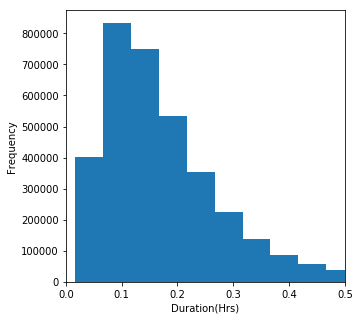

```python
## Looking at the distribution of duration_min by plotting a histogram
color=sb.color_palette()[0] # setting color to blue
bins=np.arange(bikedata_copy['duration_hrs'].min(),bikedata_copy['duration_hrs'].max()+0.05,0.05)
plt.figure(figsize=[5,5])
plt.xlim([0,0.5])
plt.hist(data=bikedata_copy,x="duration_hrs",color=color,bins=bins)
plt.xlabel("Duration(Hrs)")
plt.ylabel("Frequency")
```

Here we can see that the Duration in hrs is unimodal, having the maximum frequncy at around 0.1 hrs (6 mins). We took the x-axis limit between 0 and 0.5 to the distribution of the duration_hrs variable. We can see that around 24 hrs was the maximum

```python
bikedata_copy['distance_km'].describe()
```

```
count    3.544157e+06
mean     1.701083e+00
std      2.964921e+01
min      0.000000e+00
25%      8.883022e-01
50%      1.403156e+00
75%      2.133334e+00
max      1.280236e+04
Name: distance_km, dtype: float64
```

```python
b=np.max(bikedata_copy['distance_km'])
```

```python
b
```

```
12802.364548177206
```

```python
## Dropping the rows and columns with distance > 1000
bikedata_copy.drop(bikedata_copy.index[bikedata_copy['distance_km'] >1000],inplace=True)
```

```
Text(0,0.5,'Frequency')
```

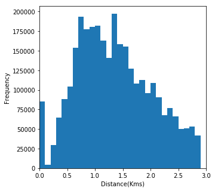

```python
## Looking at distribution of distance_km
color=sb.color_palette()[0] # setting color to blue
bins1=np.arange(bikedata_copy['distance_km'].min(),3,0.1)
plt.figure(figsize=[5,5])
plt.hist(data=bikedata_copy,x="distance_km",color=color,bins=bins1)
plt.xlim([0,3])
plt.xlabel("Distance(Kms)")
plt.ylabel("Frequency")
```

```python
## We can see that their are M,F & O we should convert them to Male,Female,Other
bikedata_copy['member_gender']= bikedata_copy['member_gender'].replace('M','Male')
bikedata_copy['member_gender']= bikedata_copy['member_gender'].replace('Maleale','Male')
bikedata_copy['member_gender']= bikedata_copy['member_gender'].replace('F','Female')
bikedata_copy['member_gender']= bikedata_copy['member_gender'].replace('O','Other')
```

```python
bikedata_copy['member_gender'].unique()
```

```
array(['Male', 'Female', 'Other'], dtype=object)
```

```python
## Lookng at the pie-chart for checking the propotion of male and female users
sorted_counts=bikedata_copy['member_gender'].value_counts()
```

```python
sorted_counts=sorted_counts.iloc[0:3]
```

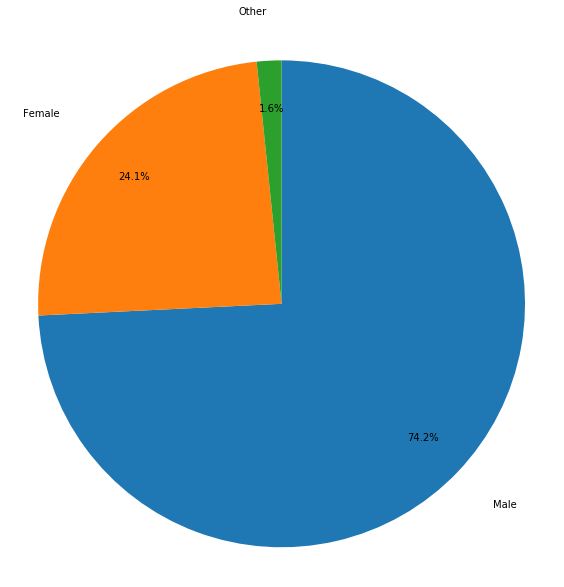

```python
##Plotting the pie chart
plt.figure(figsize=[10,10])
plt.pie(sorted_counts,labels=sorted_counts.index,startangle=90,counterclock=False,autopct='%1.1f%%',pctdistance=0.8, labeldistance=1.2)
plt.axis('square');
```

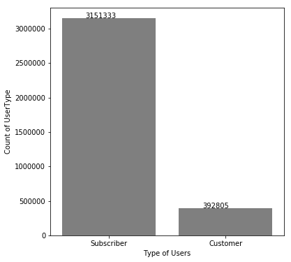

```python
## Setting the category from Subscriber and Customer
order=bikedata_copy.user_type.value_counts().index
color = sb.color_palette()[7]
plt.figure(figsize=[6,6])
ax=sb.countplot(data=bikedata_copy,x="user_type",color=color,order=order);
plt.xlabel("Type of Users")
plt.ylabel("Count of UserType")
for i in ax.patches:
    ax.text(i.get_x()+0.2,i.get_height()+300,i.get_height())
```

From the plot above we can see that the most number of user type are subscribers.

```python
## Extracting day of the week
bikedata_copy['day_of_week'] = bikedata_copy['start_time'].dt.dayofweek
days = {0:'Mon',1:'Tues',2:'Weds',3:'Thurs',4:'Fri',5:'Sat',6:'Sun'}
bikedata_copy['day_of_week'] = bikedata_copy['day_of_week'].apply(lambda x: days[x])
```

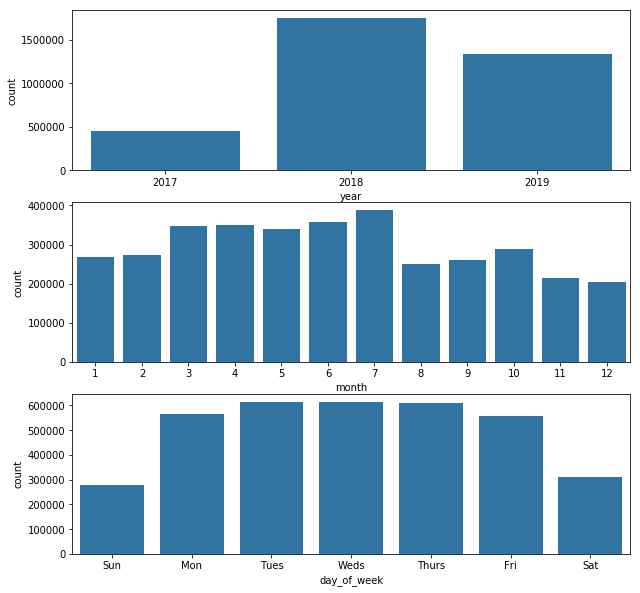

```python
##Plotting the countplot for Year,Month and day of the week
order1=['Sun','Mon','Tues','Weds','Thurs','Fri','Sat']
fig,ax =plt.subplots(nrows=3,figsize =[10,10])
color=sb.color_palette()[0]
sb.countplot(data=bikedata_copy,x='year',color=color,ax=ax[0])
sb.countplot(data=bikedata_copy,x='month',color=color,ax=ax[1])
sb.countplot(data=bikedata_copy,x='day_of_week',color=color,order=order1,ax=ax[2])

plt.show()
```

### Discuss the distribution(s) of your variable(s) of interest. Were there any unusual points? Did you need to perform any transformations?

The details realted to the distribution are given below:

1.Duration --> Here we can see that the Duration in hrs is unimodal, having the maximum frequncy at around 0.1 hrs (6 mins). We took the x-axis limit between 0 and 0.5 to the distribution of the duration_hrs variable. We can see that around 24 hrs was the maximum

4.Subscriber and Customer Countplot --> From the plot above we can see that the most number of user type are subscribers. This is true because I beleive that becoming a subscriber you only need to 15 dollars a month

### Of the features you investigated, were there any unusual distributions? Did you perform any operations on the data to tidy, adjust, or change the form of the data? If so, why did you do this?

Yes I assesced and cleaned the data before and while performing the univariate analysis

1.Converted the id variables to string

4.Converted M,F,O into male, female,others

5.Calcualted member_age

6.Calculated the distance_kms using latitude and longitude

7.Extracted day_of_the_week,month,year

8.Converted dutration in hours, easier for users to interpret

## Bivariate Exploration

In this section I would using univariate analysis to see the relationship with variables that were used in univariate analysis. To find out the relationship between them

To start with I want to look at the relationship between distance and duration

```
Text(0,0.5,'Duration(hrs)')
```

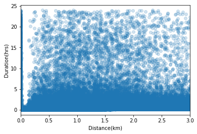

```python
sb.regplot(bikedata_copy['distance_km'],bikedata_copy['duration_hrs'],fit_reg=False,scatter_kws={'alpha':1/5})
plt.xlim([0,3])
plt.xlabel("Distance(km)")
plt.ylabel("Duration(hrs)")
```

```python
## Calculating the correlation between distance_km and duration_hrs
from scipy.stats import pearsonr
corr,_=pearsonr(bikedata_copy['distance_km'],bikedata_copy['duration_hrs'])
```

```python
corr
```

```
0.12788274776960107
```

From the plot above and the correlation coefficient value we can see that the distance in kms is not correlated to duration in hrs. We need to do some digging and see what are the other variables that are influecing the duration

Plotting the boxplot for looking at the age trend for Male and Female

```
Text(0,0.5,'Age')
```

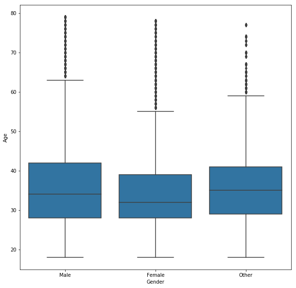

```python
plt.figure(figsize=[10,10])
color=sb.color_palette()[0]
sb.boxplot(data=bikedata_copy,x='member_gender',y='member_age',color=color);
plt.xlabel("Gender")
plt.ylabel("Age")
```

Plotting clustered bar graph to check the count of subscribers & customers by year,month and weekday

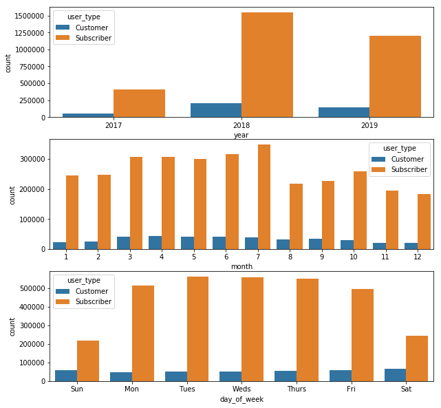

```python
fig,ax =plt.subplots(nrows=3,figsize =[10,10])
order2=['Sun','Mon','Tues','Weds','Thurs','Fri','Sat']
sb.countplot(data=bikedata_copy,x='year',hue='user_type',ax=ax[0])
sb.countplot(data=bikedata_copy,x='month',hue='user_type',ax=ax[1])
sb.countplot(data=bikedata_copy,x='day_of_week',hue='user_type',ax=ax[2],order=order2);
```

```python
def log_trans(x,inverse=False):
    if not inverse:
        return np.log10(x)
    else:
        return np.power(10,x)
```

```
Text(0,0.5,'Duration(Hrs)')
```

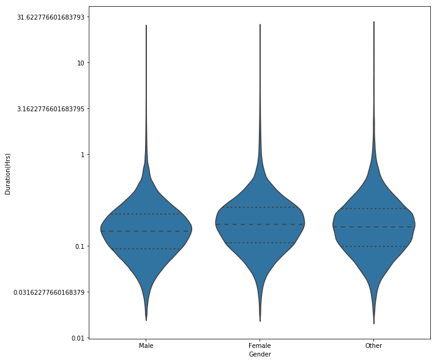

```python
plt.figure(figsize=[10,10])
base_color = sb.color_palette()[0]
sb.violinplot(bikedata_copy['member_gender'],bikedata_copy['duration_hrs'].apply(log_trans),color=base_color,inner='quartile');
ticks=[0.01, 0.03162277660168379, 0.1, 1, 3.1622776601683795, 10, 31.622776601683793]
plt.yticks(log_trans(np.array(ticks)),ticks)
plt.xlabel("Gender");
plt.ylabel("Duration(Hrs)")
```

From this plot we can see that the median duration for women and other gender type is more than the male gender type. I belive that the type of gender also influences your duration

Plotting the clusterred bar chart to see the number of Male,Female and other subscribers by Year, month and day_of_the_week

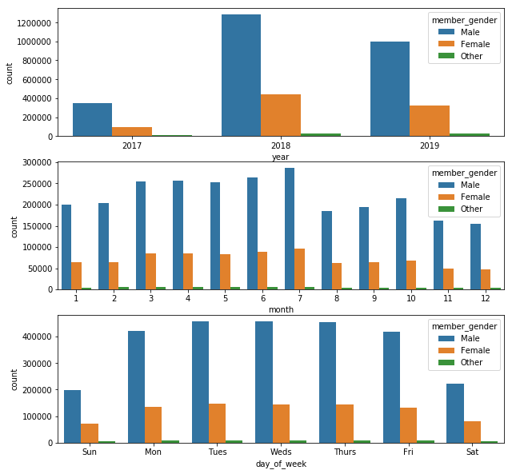

```python
fig,ax =plt.subplots(nrows=3,figsize =[10,10])
order2=['Sun','Mon','Tues','Weds','Thurs','Fri','Sat']
sb.countplot(data=bikedata_copy,x='year',hue='member_gender',ax=ax[0])
sb.countplot(data=bikedata_copy,x='month',hue='member_gender',ax=ax[1])
sb.countplot(data=bikedata_copy,x='day_of_week',hue='member_gender',ax=ax[2],order=order2);
```

From this plot we were able to see that there are more male users using the bay wheels bike for commting from one place to another

Using Facetting plot bike_share for all trips between different gender types

```python
group_count=bikedata_copy.groupby('bike_share_for_all_trip').count()
```

```python
group_count
```

| bike_share_for_all_trip | bike_id | duration_sec | end_station_id | end_station_latitude | end_station_longitude | end_station_name | end_time | member_birth_year | member_gender | start_station_id | ... | year | day | starttime | endtime | month | hour | member_age | distance_km | duration_hrs | day_of_week |
| --- | --- | --- | --- | --- | --- | --- | --- | --- | --- | --- | --- | --- | --- | --- | --- | --- | --- | --- | --- | --- | --- |
| No | 2791593 | 2791593 | 2791593 | 2791593 | 2791593 | 2780288 | 2791593 | 2791593 | 2791593 | 2791593 | ... | 2791593 | 2791593 | 2791593 | 2791593 | 2791593 | 2791593 | 2791593 | 2791593 | 2791593 | 2791593 |
| Yes | 274739 | 274739 | 274739 | 274739 | 274739 | 273862 | 274739 | 274739 | 274739 | 274739 | ... | 274739 | 274739 | 274739 | 274739 | 274739 | 274739 | 274739 | 274739 | 274739 | 274739 |

2 rows × 25 columns

```python
group_order=group_count.sort_values('bike_id',ascending=False).index
```

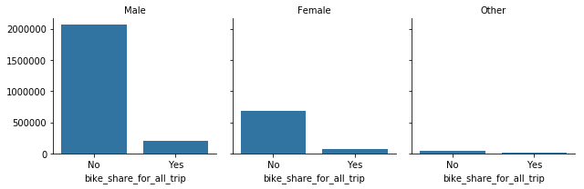

```python
g=sb.FacetGrid(data=bikedata_copy,col='member_gender',col_wrap=3,size=3)
g.map(sb.countplot,'bike_share_for_all_trip',order=group_order);
g.set_titles('{col_name}')
```

I am amazed to see that very less number of people use bike share for all their rides. I think it might be because of less availability

### Did you observe any interesting relationships between the other features (not the main feature(s) of interest)?

1.The median age is high, I was expecting somewhere around 28 because there are lot of student users in bay. Secondly not a lot of people share bike for their travel

## Multivariate Exploration

> Create plots of three or more variables to investigate your data even further. Make sure that your investigations are justified, and follow from your work in the previous sections.

The main question I want to see how the distance and duration is affected and what is bike usage over the different day_of the week,month and year. Also want to see what is usage of gender type

Looking at duration by day of the week and gender

```python
group1_count=bikedata_copy.groupby('member_gender').count()
```

```python
group1_count
```

| member_gender | bike_id | bike_share_for_all_trip | duration_sec | end_station_id | end_station_latitude | end_station_longitude | end_station_name | end_time | member_birth_year | start_station_id | ... | year | day | starttime | endtime | month | hour | member_age | distance_km | duration_hrs | day_of_week |
| --- | --- | --- | --- | --- | --- | --- | --- | --- | --- | --- | --- | --- | --- | --- | --- | --- | --- | --- | --- | --- | --- |
| Female | 855316 | 751886 | 855316 | 855316 | 855316 | 855316 | 849337 | 855316 | 855316 | 855316 | ... | 855316 | 855316 | 855316 | 855316 | 855316 | 855316 | 855316 | 855316 | 855316 | 855316 |
| Male | 2630941 | 2263243 | 2630941 | 2630941 | 2630941 | 2630941 | 2609725 | 2630941 | 2630941 | 2630941 | ... | 2630941 | 2630941 | 2630941 | 2630941 | 2630941 | 2630941 | 2630941 | 2630941 | 2630941 | 2630941 |
| Other | 57881 | 51203 | 57881 | 57881 | 57881 | 57881 | 57479 | 57881 | 57881 | 57881 | ... | 57881 | 57881 | 57881 | 57881 | 57881 | 57881 | 57881 | 57881 | 57881 | 57881 |

3 rows × 25 columns

```python
group1_order=group1_count.sort_values('bike_id',ascending=False).index
```

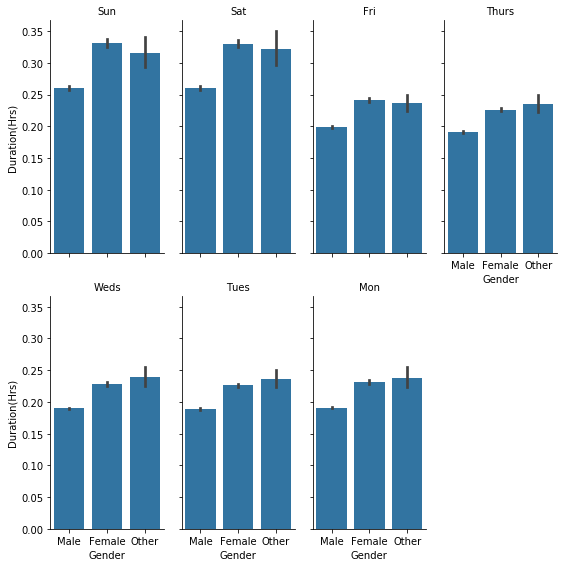

```python
g=sb.FacetGrid(data=bikedata_copy,col='day_of_week',col_wrap=4,size=4,aspect=.5,margin_titles=True)
g.map(sb.barplot,'member_gender','duration_hrs',order=group1_order)
g.set_titles('{col_name}')
g.set_axis_labels("Gender","Duration(Hrs)")
```

From the plot above we can see that the Male on an average everyday spends less time travelling from point A ie starting point to pint B that is the ending point

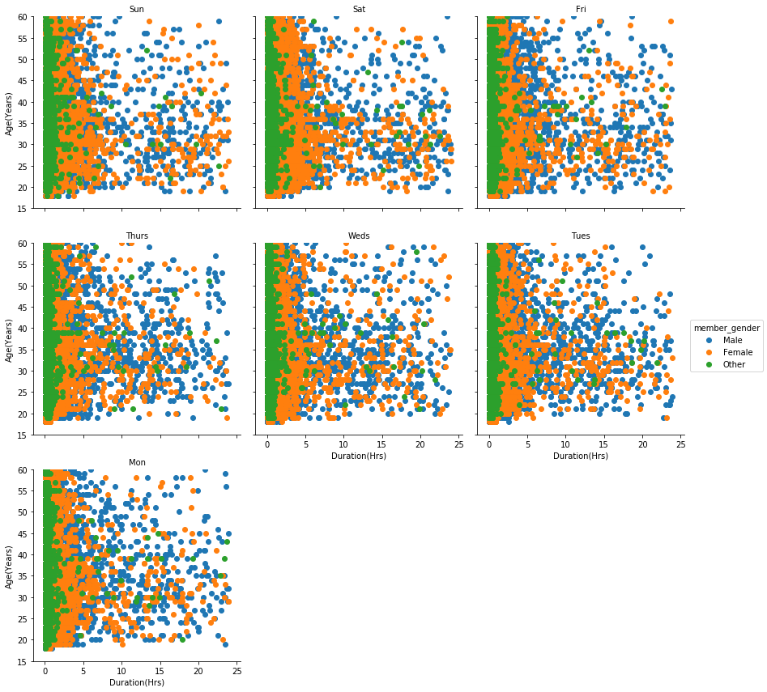

```python
g=sb.FacetGrid(data=bikedata_copy,hue='member_gender', size=4, col='day_of_week',col_wrap=3);
g.map(plt.scatter,'duration_hrs','member_age');
g.add_legend();
g.set(ylim=(15,60));
g.set_axis_labels("Duration(Hrs)","Age(Years)");
g.set_titles('{col_name}');
```

```python
corr1,_ =pearsonr(bikedata_copy['duration_hrs'],bikedata_copy['member_age'])
```

```python
corr1
```

```
0.001086178492067428
```

We can see that with increase in sage duration to travel also increases but it is for some wafers. We can see that Age is not that correlated to Duration in hrs using the pearson correlation coefficient which 0.001086. I think their might be external factors effecting the duration for eg: Traffic congestion etc and Bay-Area is famous for that

```python
## Calculating sample size
## Inmporting the math library
import math
# SUPPORTED CONFIDENCE LEVELS: 50%, 68%, 90%, 95%, and 99%
confidence_level_constant = [50,.67], [68,.99], [90,1.64], [95,1.96], [99,2.57]

# CALCULATE THE SAMPLE SIZE
def sample_size(population_size, confidence_level, confidence_interval):
  Z = 0.0
  p = 0.5
  e = confidence_interval/100.0
  N = population_size
  n_0 = 0.0
  n = 0.0

  # LOOP THROUGH SUPPORTED CONFIDENCE LEVELS AND FIND THE NUM STD
  # DEVIATIONS FOR THAT CONFIDENCE LEVEL
  for i in confidence_level_constant:
    if i[0] == confidence_level:
      Z = i[1]

  if Z == 0.0:
    return -1

  # CALC SAMPLE SIZE
  n_0 = ((Z**2) * p * (1-p)) / (e**2)

  # ADJUST SAMPLE SIZE FOR FINITE POPULATION
  n = n_0 / (1 + ((n_0 - 1) / float(N)) )

  return int(math.ceil(n)) # THE SAMPLE SIZE
```

```python
def main():
    sample_sz=0
    population_sz = bikedata_copy.shape[0]
    confidence_level = 95.0
    confidence_interval = 2.0
    sample_sz = sample_size(population_sz, confidence_level, confidence_interval)
    print ("SAMPLE SIZE: {}" .format(sample_sz))

if __name__ == "__main__":
    main()
```

```
SAMPLE SIZE: 2400
```

```python
## With 95% confidence interval and marginal error 2% sample size is 2400
bikedata_copy_sample=bikedata_copy.sample(2400)
```

```python
## Creating groups for the members age depending upon the age range
d=[]
for s in bikedata_copy_sample['member_age']:
    if 10<s<=20:
        a='10-20'
        d.append(a)
    elif 20<s<=30:
        a='20-30'
        d.append(a)
    elif 30<s<=40:
        a='30-40'
        d.append(a)
    elif 40<s<=50:
        a='40-50'
        d.append(a)
    elif 50<s<=60:
        a='50-60'
        d.append(a)
    elif 60<s<=70:
        a='60-70'
        d.append(a)
    else:
        a=s
        d.append(a)
```

```python
##Naming the months
k=[]
for h in bikedata_copy_sample['month']:
    if h==1:
        a='Jan'
        k.append(a)
    elif h==2:
        a='Feb'
        k.append(a)
    elif h==3:
        a='March'
        k.append(a)
    elif h==4:
        a='April'
        k.append(a)
    elif h==5:
        a='May'
        k.append(a)
    elif h==6:
        a='June'
        k.append(a)
    elif h==7:
        a='July'
        k.append(a)
    elif h==8:
        a="August"
        k.append(a)
    elif h==9:
        a="Sept"
        k.append(a)
    elif h==10:
        a="Oct"
        k.append(a)
    elif h==11:
        a="Nov"
        k.append(a)
    elif h==12:
        a="Dec"
        k.append(a)
```

```python
bikedata_copy_sample['age_group']=d
```

```python
bikedata_copy_sample['month_name']=k
```

```python
bikedata_copy_sample['year_month']=bikedata_copy_sample['start_time'].dt.strftime('%y'+'-'+'%m')
```

```python
bikedata_copy_sample.head()
```

|  | bike_id | bike_share_for_all_trip | duration_sec | end_station_id | end_station_latitude | end_station_longitude | end_station_name | end_time | member_birth_year | member_gender | ... | endtime | month | hour | member_age | distance_km | duration_hrs | day_of_week | age_group | month_name | year_month |
| --- | --- | --- | --- | --- | --- | --- | --- | --- | --- | --- | --- | --- | --- | --- | --- | --- | --- | --- | --- | --- | --- |
| 433100 | 167 | NaN | 441 | 62.0 | 37.777791 | -122.406432 | Victoria Manalo Draves Park | 2017-08-17 09:00:58.357 | 1983.0 | Male | ... | 09:00:58.357000 | 8 | 8 | 36.0 | 0.967290 | 0.122500 | Thurs | 30-40 | August | 17-08 |
| 3450516 | 2941 | No | 452 | 67.0 | 37.776639 | -122.395526 | San Francisco Caltrain Station 2 (Townsend St... | 2019-06-28 08:37:37.867 | 1993.0 | Female | ... | 08:37:37.867000 | 6 | 8 | 26.0 | 1.454068 | 0.125556 | Fri | 20-30 | June | 19-06 |
| 3234397 | 4633 | No | 1462 | 355.0 | 37.755367 | -122.388795 | 23rd St at Tennessee St | 2019-04-03 08:22:26.979 | 1986.0 | Female | ... | 08:22:26.979000 | 4 | 7 | 33.0 | 4.318934 | 0.406111 | Weds | 30-40 | April | 19-04 |
| 3374858 | 1045 | No | 1078 | 257.0 | 37.870407 | -122.299676 | Fifth St at Delaware St | 2019-05-10 11:05:39.165 | 1989.0 | Female | ... | 11:05:39.165000 | 5 | 10 | 30.0 | 2.744418 | 0.299444 | Fri | 20-30 | May | 19-05 |
| 3206551 | 2427 | No | 535 | 130.0 | 37.757288 | -122.392051 | 22nd St Caltrain Station | 2019-04-05 18:32:20.467 | 1983.0 | Male | ... | 18:32:20.467000 | 4 | 18 | 36.0 | 1.090448 | 0.148611 | Fri | 30-40 | April | 19-04 |

5 rows × 29 columns

```python
## grouping the data member_gender
group2=bikedata_copy_sample.groupby('member_gender').count()
```

```python
group2_order=group2.sort_values('bike_id',ascending=False).index
```

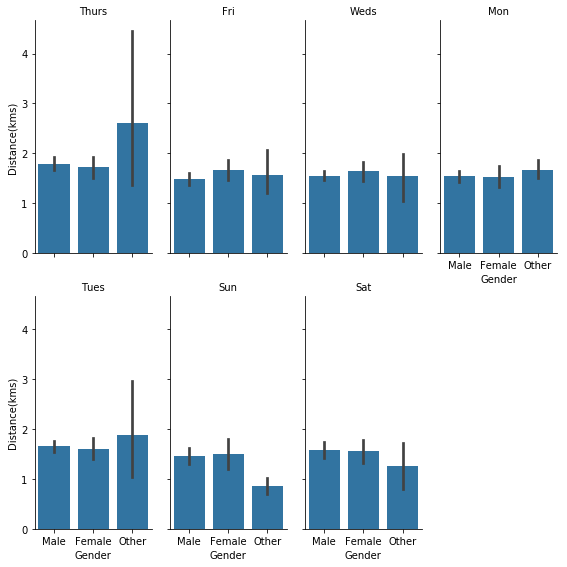

```python
## Plottiing distance covered by day of the week and by gender
g=sb.FacetGrid(data=bikedata_copy_sample,col='day_of_week',col_wrap=4,size=4,aspect=.5,margin_titles=True)
g.map(sb.barplot,'member_gender','distance_km',order=group1_order)
g.set_titles('{col_name}');
g.set_axis_labels("Gender","Distance(kms)");
```

Yearly Usage of Bike by memeber_gender and user_type

```python
group3=bikedata_copy_sample.groupby(['year','member_gender','user_type']).count()['bike_id']
```

```python
group3=group3.reset_index(name='count')
```

```python
group3
```

|  | year | member_gender | user_type | count |
| --- | --- | --- | --- | --- |
| 0 | 2017 | Female | Customer | 9 |
| 1 | 2017 | Female | Subscriber | 62 |
| 2 | 2017 | Male | Customer | 15 |
| 3 | 2017 | Male | Subscriber | 226 |
| 4 | 2017 | Other | Customer | 1 |
| 5 | 2017 | Other | Subscriber | 2 |
| 6 | 2018 | Female | Customer | 40 |
| 7 | 2018 | Female | Subscriber | 221 |
| 8 | 2018 | Male | Customer | 106 |
| 9 | 2018 | Male | Subscriber | 790 |
| 10 | 2018 | Other | Customer | 4 |
| 11 | 2018 | Other | Subscriber | 14 |
| 12 | 2019 | Female | Customer | 29 |
| 13 | 2019 | Female | Subscriber | 202 |
| 14 | 2019 | Male | Customer | 59 |
| 15 | 2019 | Male | Subscriber | 606 |
| 16 | 2019 | Other | Customer | 1 |
| 17 | 2019 | Other | Subscriber | 13 |

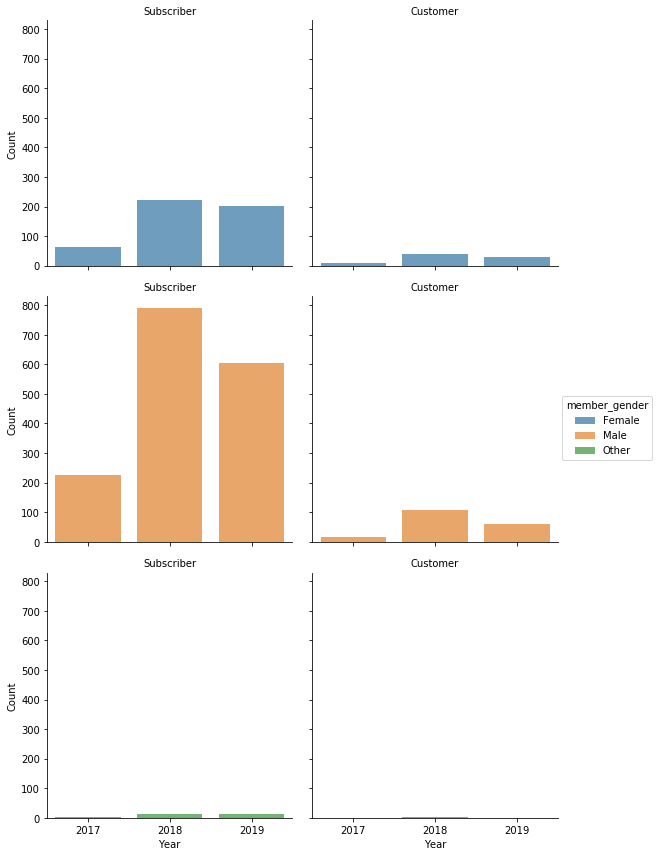

```python
g=sb.FacetGrid(data=group3,col='user_type',row='member_gender',hue='member_gender',size=4,col_order=['Subscriber','Customer']);
g=g.map(sb.barplot,'year','count',alpha=0.7);
g.add_legend()
g.set_axis_labels("Year","Count");
g.set_titles('{col_name}')
```

```python
## Filtering the data by only subscribers to check their monthly,daily,hourly usage
bike_subscribers=bikedata_copy_sample[bikedata_copy_sample['user_type']=="Subscriber"]
```

```python
group4=bike_subscribers.groupby(['year_month','member_gender','age_group']).count()['bike_id']
```

```python
group4=group4.reset_index(name='usage')
```

```
Text(0,0.5,'Usage')
```

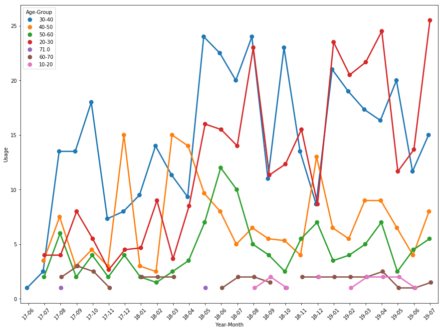

```python
plt.figure(figsize=[15,11])
g=sb.pointplot(data=group4,x="year_month",y="usage",hue="age_group",ci=None,dodge=True);
plt.xticks(rotation=45)
ax=g.legend()
ax.set_title("Age-Group")
plt.xlabel("Year-Month")
plt.ylabel("Usage")
```

From the plot we can see that more users from the age 20-40 are using the bike for their rides. We can also see that in 2018 30-40 year people were using the bike more; but in the later part of the 2019 we can see 20-30 year old users start using Bike more

```
Text(0,0.5,'Usage')
```

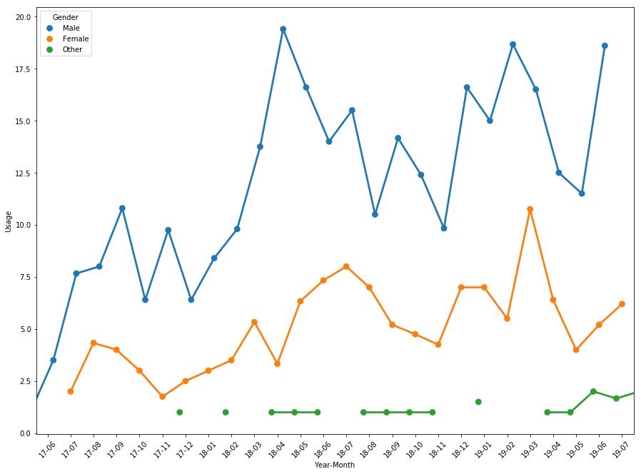

```python
plt.figure(figsize=[15,11])
g=sb.pointplot(data=group4,x="year_month",y="usage",hue="member_gender",ci=None,dodge=1.5);
plt.xticks(rotation=45)
ax=g.legend()
ax.set_title("Gender")
plt.xlabel("Year-Month")
plt.ylabel("Usage")
```

If we look at the plot we can see that over 3 years, Male and Female Gender under 40 years have same kind of trend for the bike usage. Other gender category have some missing points;this means most of their users, till July'18 were not a regular user

```python
##Looking at hourly usage of the bikes by subsriber,customer based upon bike_share_for_all_trip
```

```python
bike_Customer=bikedata_copy_sample[bikedata_copy_sample['user_type']=='Customer']
```

```python
group5=bike_Customer.groupby(['hour','user_type','bike_share_for_all_trip']).count()['bike_id']
```

```python
group5=group5.reset_index(name='usage')
```

```python
group6=bike_subscribers.groupby(['hour','user_type','bike_share_for_all_trip']).count()['bike_id']
```

```python
group6=group6.reset_index(name='usage')
```

```python
group6.head()
```

|  | hour | user_type | bike_share_for_all_trip | usage |
| --- | --- | --- | --- | --- |
| 0 | 0 | Subscriber | No | 6 |
| 1 | 0 | Subscriber | Yes | 1 |
| 2 | 1 | Subscriber | No | 3 |
| 3 | 2 | Subscriber | No | 1 |
| 4 | 3 | Subscriber | No | 2 |

```
Text(0,0.5,'Usage')
```

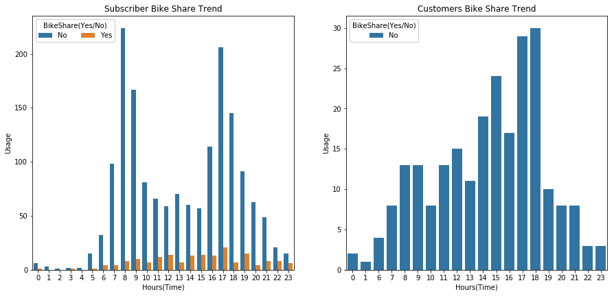

```python
plt.figure(figsize=[15,15])
plt.subplot(221)
ax=sb.barplot(data=group6,x="hour",y="usage",hue="bike_share_for_all_trip");
plt.title("Subscriber Bike Share Trend")
ax.legend(loc=2,ncol=2,framealpha=1,title="BikeShare(Yes/No)")
plt.xlabel("Hours(Time)")
plt.ylabel("Usage")
plt.subplot(222)
ax=sb.barplot(data=group5,x="hour",y="usage",hue="bike_share_for_all_trip");
plt.title("Customers Bike Share Trend")
ax.legend(loc=2,ncol=2,framealpha=1,title="BikeShare(Yes/No)")
plt.xlabel("Hours(Time)")
plt.ylabel("Usage")
```

```python
##Now looking at the trend of the mean duration and mean taken by subscriber to complete their trip(Only for Subscribers)
group7=bike_subscribers.groupby(['hour','bike_share_for_all_trip']).mean()['duration_hrs']
```

```python
group7=group7.reset_index(name='mean_duration')
```

```python
group8=bike_subscribers.groupby(['hour','bike_share_for_all_trip']).median()['distance_km']
```

```python
group8=group8.reset_index(name='median_distance')
```

```
Text(0,0.5,'Median Distance(kms)')
```

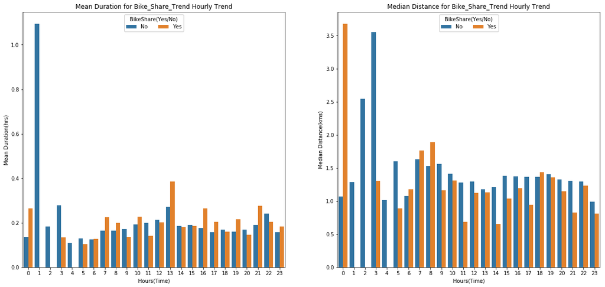

```python
plt.figure(figsize=[20,20])
plt.subplot(221)
ax=sb.barplot(data=group7,x='hour',y='mean_duration',hue='bike_share_for_all_trip');
plt.title("Mean Duration for Bike_Share_Trend Hourly Trend")
ax.legend(loc=9,ncol=2,framealpha=1,title="BikeShare(Yes/No)")
plt.xlabel("Hours(Time)")
plt.ylabel("Mean Duration(hrs)")
plt.subplot(222)
ax=sb.barplot(data=group8,x='hour',y='median_distance',hue='bike_share_for_all_trip');
plt.title("Median Distance for Bike_Share_Trend Hourly Trend")
ax.legend(loc=9,ncol=2,framealpha=1,title="BikeShare(Yes/No)")
plt.xlabel("Hours(Time)")
plt.ylabel("Median Distance(kms)")
```

```python
bikedata_copy.to_csv("CleanBike.csv",index=False,encoding='utf-8')
```

### Were there any interesting or surprising interactions between features?

The interaction between certain variables helped me in understanding different aspects. Adding Gender to Duration, and distance travelled everyday helped in understanding the fact that why duration is less correlated with distance. Combining Hours,age, bike share, duration and time helped understanding the facts of people that use the bike for all trips or not

### Key Challenges

1.Programatically Extracting the data from s3

2.Data had Tideness and Quality Issues

3.My computer was really slow in plotting, so I created the formula for sample size using google and used the sample data for plotting few multivariate plots

> At the end of your report, make sure that you export the notebook as an html file from the `File > Download as... > HTML` menu. Make sure you keep track of where the exported file goes, so you can put it in the same folder as this notebook for project submission. Also, make sure you remove all of the quote-formatted guide notes like this one before you finish your report!